# Final_Advanced_Modeling

Sude Boz 100569570

2026-03-22

```r
knitr::opts_chunk$set(echo = TRUE, warning = FALSE, message = FALSE)
```

# Introduction

This project is using the `war economic impact` dataset from kaggle. The dataset consists 100,000 observations of conflicts with 28 variables such as socioeconomic indicators such as unemployment, poverty, inflation, and black market activity; and information about conflicts across different regions, types, and time periods.

The goal is to apply supervised learning techniques in two tasks:

- **Classification**: predict the level of black market activity (`Black_Market_Activity_Level`: Low, Moderate, High, Dominant)
- **Regression**: predict the percentage change in GDP during the conflict (`GDP_Change`)

```r
#libraries
library(tidyverse)
library(DataExplorer)
library(ggplot2)
library(knitr)
library(caret)
library(MASS)
library(e1071)
library(tree)
library(randomForest)
library(olsrr)
library(pls)
```

```r
data_original <- read_csv("war_economic_impact_dataset.csv")
```

```r
dim(data_original)
```

```
## [1] 100000     28
```

```r
glimpse(data_original)
```

```
## Rows: 100,000
## Columns: 28
## $ Conflict_Name                           <chr> "WWII (Japan)", "Israel-Hamas …
## $ Conflict_Type                           <chr> "World War", "Asymmetric War",…
## $ Region                                  <chr> "East Asia", "Middle East", "M…
## $ Start_Year                              <dbl> 1939, 2023, 2011, 1939, 2001, …
## $ End_Year                                <dbl> 1945, 2026, 2026, 1945, 2021, …
## $ Status                                  <chr> "Resolved", "Ongoing", "Ongoin…
## $ Primary_Country                         <chr> "Japan", "Palestine (Gaza)", "…
## $ `Pre_War_Unemployment_%`                <dbl> 7.49, 8.18, 12.70, 14.06, 5.38…
## $ `During_War_Unemployment_%`             <dbl> 21.78, 23.00, 36.46, 17.83, 5.…
## $ Unemployment_Spike_Percentage_Points    <dbl> 14.29, 14.82, 23.76, 3.77, 0.5…
## $ Most_Affected_Sector                    <chr> "Construction", "Tourism", "To…
## $ `Youth_Unemployment_Change_%`           <dbl> 19.90, 19.92, 27.06, 4.44, 0.8…
## $ `Pre_War_Poverty_Rate_%`                <dbl> 19.97, 8.49, 22.11, 6.13, 22.6…
## $ `During_War_Poverty_Rate_%`             <dbl> 28.67, 18.93, 41.31, 8.87, 23.…
## $ `Extreme_Poverty_Rate_%`                <dbl> 10.39, 8.45, 14.41, 4.04, 14.1…
## $ `Food_Insecurity_Rate_%`                <dbl> 15.00, 12.92, 28.83, 5.40, 12.…
## $ Households_Fallen_Into_Poverty_Estimate <dbl> 38487, 166213, 114129, 1916, 4…
## $ `GDP_Change_%`                          <dbl> -36.86, -64.99, -19.03, -42.29…
## $ `Inflation_Rate_%`                      <dbl> 97.41, 73.68, 69.35, 36.92, 52…
## $ `Currency_Devaluation_%`                <dbl> 170.33, 41.97, 53.91, 48.51, 3…
## $ Cost_of_War_USD                         <dbl> 106957216228, 304164881098, 48…
## $ Estimated_Reconstruction_Cost_USD       <dbl> 2.090546e+11, 5.859159e+11, 1.…
## $ `Informal_Economy_Size_Pre_War_%`       <dbl> 15.50, 11.95, 38.18, 12.24, 31…
## $ `Informal_Economy_Size_During_War_%`    <dbl> 27.09, 34.76, 90.00, 36.42, 74…
## $ Black_Market_Activity_Level             <chr> "High", "Dominant", "Moderate"…
## $ Primary_Black_Market_Goods              <chr> "food", "fuel", "water, weapon…
## $ `Currency_Black_Market_Rate_Gap_%`      <dbl> 10.50, 19.31, 298.95, 15.44, 4…
## $ War_Profiteering_Documented             <chr> "No", "No", "No", "No", "Yes",…
```

```r
summary(data_original)
```

```
##  Conflict_Name      Conflict_Type         Region            Start_Year
##  Length:100000      Length:100000      Length:100000      Min.   :1939
##  Class :character   Class :character   Class :character   1st Qu.:1996
##  Mode  :character   Mode  :character   Mode  :character   Median :2011
##                                                           Mean   :1999
##                                                           3rd Qu.:2022
##                                                           Max.   :2025
##     End_Year       Status          Primary_Country    Pre_War_Unemployment_%
##  Min.   :1945   Length:100000      Length:100000      Min.   : 3.000
##  1st Qu.:2011   Class :character   Class :character   1st Qu.: 6.030
##  Median :2026   Mode  :character   Mode  :character   Median : 9.020
##  Mean   :2009                                         Mean   : 9.017
##  3rd Qu.:2026                                         3rd Qu.:12.000
##  Max.   :2026                                         Max.   :15.000
##  During_War_Unemployment_% Unemployment_Spike_Percentage_Points
##  Min.   : 3.36             Min.   : 0.32
##  1st Qu.:12.78             1st Qu.: 5.33
##  Median :19.48             Median :10.22
##  Mean   :22.63             Mean   :13.61
##  3rd Qu.:28.80             3rd Qu.:17.89
##  Max.   :89.40             Max.   :74.47
##  Most_Affected_Sector Youth_Unemployment_Change_% Pre_War_Poverty_Rate_%
##  Length:100000        Min.   :  0.36              Min.   : 5.00
##  Class :character     1st Qu.:  6.86              1st Qu.:11.26
##  Mode  :character     Median : 13.24              Median :17.52
##                       Mean   : 17.69              Mean   :17.52
##                       3rd Qu.: 23.27              3rd Qu.:23.79
##                       Max.   :108.71              Max.   :30.00
##  During_War_Poverty_Rate_% Extreme_Poverty_Rate_% Food_Insecurity_Rate_%
##  Min.   : 5.40             Min.   : 1.84          Min.   : 3.10
##  1st Qu.:20.03             1st Qu.: 9.27          1st Qu.:13.49
##  Median :27.63             Median :13.20          Median :18.80
##  Mean   :29.08             Mean   :14.55          Mean   :20.35
##  3rd Qu.:35.29             3rd Qu.:18.25          3rd Qu.:25.20
##  Max.   :98.00             Max.   :68.49          Max.   :86.32
##  Households_Fallen_Into_Poverty_Estimate  GDP_Change_%    Inflation_Rate_%
##  Min.   :       1                        Min.   :-85.00   Min.   :  0.03
##  1st Qu.:    5711                        1st Qu.:-42.21   1st Qu.: 42.71
##  Median :   22104                        Median :-29.70   Median : 69.29
##  Mean   :  159762                        Mean   :-31.61   Mean   : 69.95
```

[output cut: 15 more lines]

```
##  Max.   :40.00                   Max.   :90.00
##  Black_Market_Activity_Level Primary_Black_Market_Goods
##  Length:100000               Length:100000
##  Class :character            Class :character
##  Mode  :character            Mode  :character
##
##
##
##  Currency_Black_Market_Rate_Gap_% War_Profiteering_Documented
##  Min.   :  0.00                   Length:100000
##  1st Qu.:  9.33                   Class :character
##  Median : 18.76                   Mode  :character
##  Mean   :126.18
##  3rd Qu.:241.43
##  Max.   :500.00
```

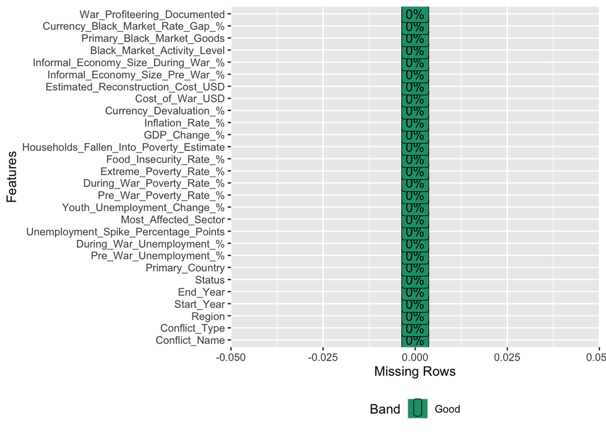

```r
# missing values
plot_missing(data_original)
```

## Data Cleaning

The dataset contains 100,000 observations and this might create difficulties in modelling in terms of time. Due to the computational cost of modelling on 100,000 observations, a random sample of 5,000 was drawn using a fixed seed (2026) for reproducibility, which remains well above the required threshold.

```r
# Keep a representative random sample for computational efficiency
set.seed(2026)
data <- data_original |> sample_n(5000)
```

### Checking missing and duplicates

```r
cat("NAs in data:", sum(is.na(data)), "\n")
```

```
## NAs in data: 0
```

```r
cat("Duplicated rows:", sum(duplicated(data)), "\n")
```

```
## Duplicated rows: 0
```

No missing values or duplicated rows are found, so no imputation or deduplication is needed.

### Rename Columns

Column names with `%` symbols can cause issues in R. We rename them to clean names.

```r
data <- data |>
  rename(
    Pre_War_Unemployment     = `Pre_War_Unemployment_%`,
    During_War_Unemployment  = `During_War_Unemployment_%`,
    Unemployment_Spike       = `Unemployment_Spike_Percentage_Points`,
    Youth_Unemployment_Change = `Youth_Unemployment_Change_%`,
    Pre_War_Poverty          = `Pre_War_Poverty_Rate_%`,
    During_War_Poverty       = `During_War_Poverty_Rate_%`,
    Extreme_Poverty          = `Extreme_Poverty_Rate_%`,
    Food_Insecurity          = `Food_Insecurity_Rate_%`,
    GDP_Change               = `GDP_Change_%`,
    Inflation_Rate           = `Inflation_Rate_%`,
    Currency_Devaluation     = `Currency_Devaluation_%`,
    Informal_PreWar          = `Informal_Economy_Size_Pre_War_%`,
    Informal_During          = `Informal_Economy_Size_During_War_%`,
    Black_Market_Gap         = `Currency_Black_Market_Rate_Gap_%`
  )

cat("Columns after renaming:\n")
```

```
## Columns after renaming:
```

```r
names(data)
```

```
##  [1] "Conflict_Name"
##  [2] "Conflict_Type"
##  [3] "Region"
##  [4] "Start_Year"
##  [5] "End_Year"
##  [6] "Status"
##  [7] "Primary_Country"
##  [8] "Pre_War_Unemployment"
##  [9] "During_War_Unemployment"
## [10] "Unemployment_Spike"
## [11] "Most_Affected_Sector"
## [12] "Youth_Unemployment_Change"
## [13] "Pre_War_Poverty"
## [14] "During_War_Poverty"
## [15] "Extreme_Poverty"
## [16] "Food_Insecurity"
## [17] "Households_Fallen_Into_Poverty_Estimate"
## [18] "GDP_Change"
## [19] "Inflation_Rate"
## [20] "Currency_Devaluation"
## [21] "Cost_of_War_USD"
## [22] "Estimated_Reconstruction_Cost_USD"
## [23] "Informal_PreWar"
## [24] "Informal_During"
## [25] "Black_Market_Activity_Level"
## [26] "Primary_Black_Market_Goods"
## [27] "Black_Market_Gap"
## [28] "War_Profiteering_Documented"
```

## Derived Variable: Conflict Duration

We create a new variable representing the duration of each conflict in years, which may be a useful predictor:

```r
data <- data |>
  mutate(Conflict_Duration = End_Year - Start_Year)

cat("Conflict_Duration range:", min(data$Conflict_Duration), "to", max(data$Conflict_Duration), "years\n")
```

```
## Conflict_Duration range: 1 to 30 years
```

# EDA

### Distribution of continuous variables and GDP_Change

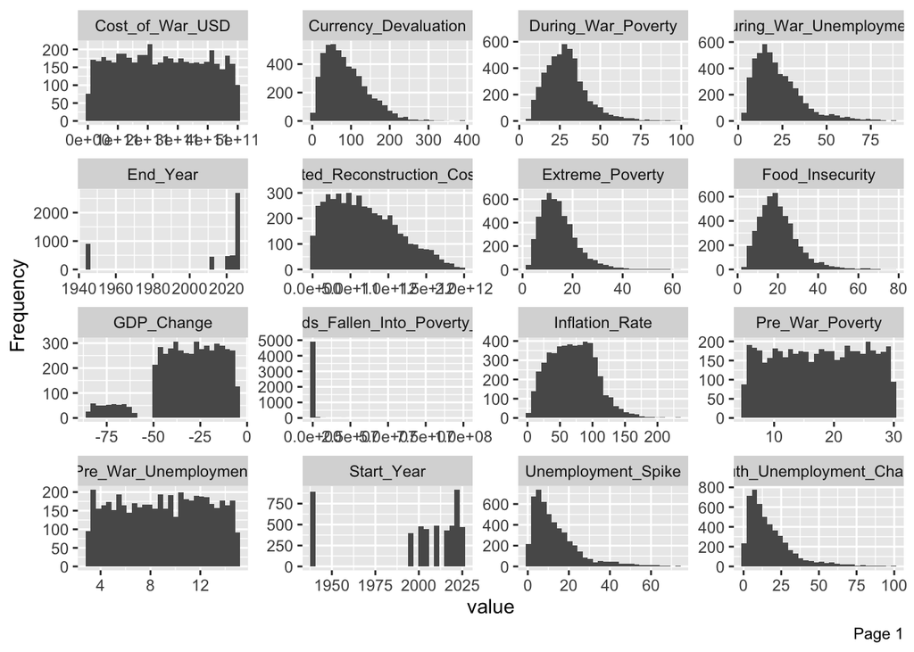

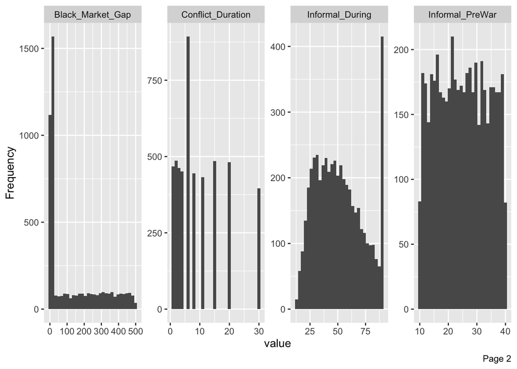

```r
plot_histogram(data)
```

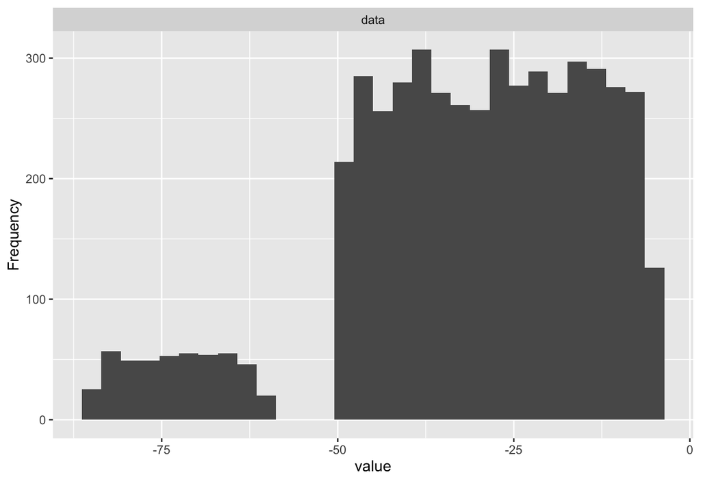

```r
plot_histogram(data$GDP_Change)
```

All GDP values are between -85 and -5. We can say that in every terms the wars has narrowed the economy.

### Distribution of discrete variables and Black Market activity level

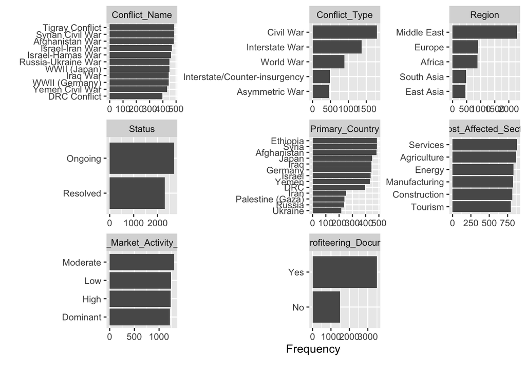

```r
plot_bar(data)
```

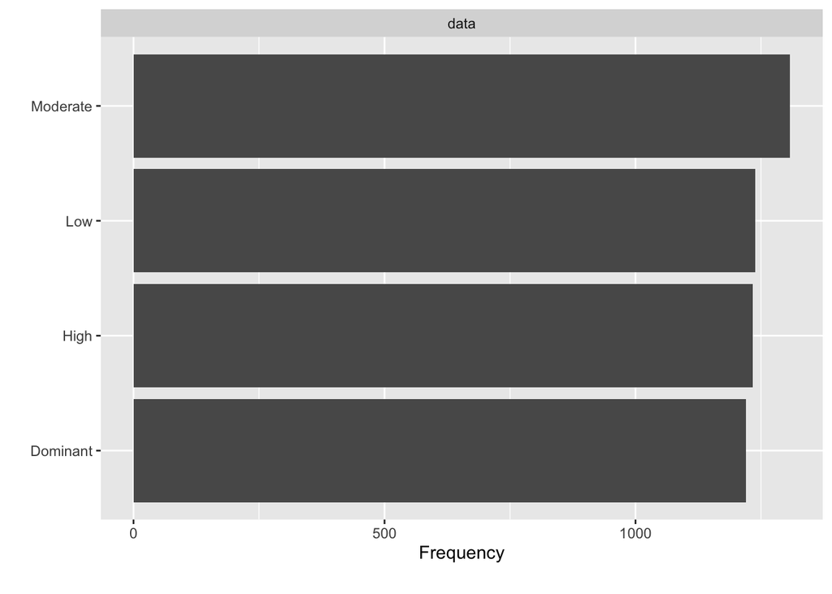

```r
plot_bar(data$Black_Market_Activity_Level)
```

### GDP Change by Conflict Type (boxplot)

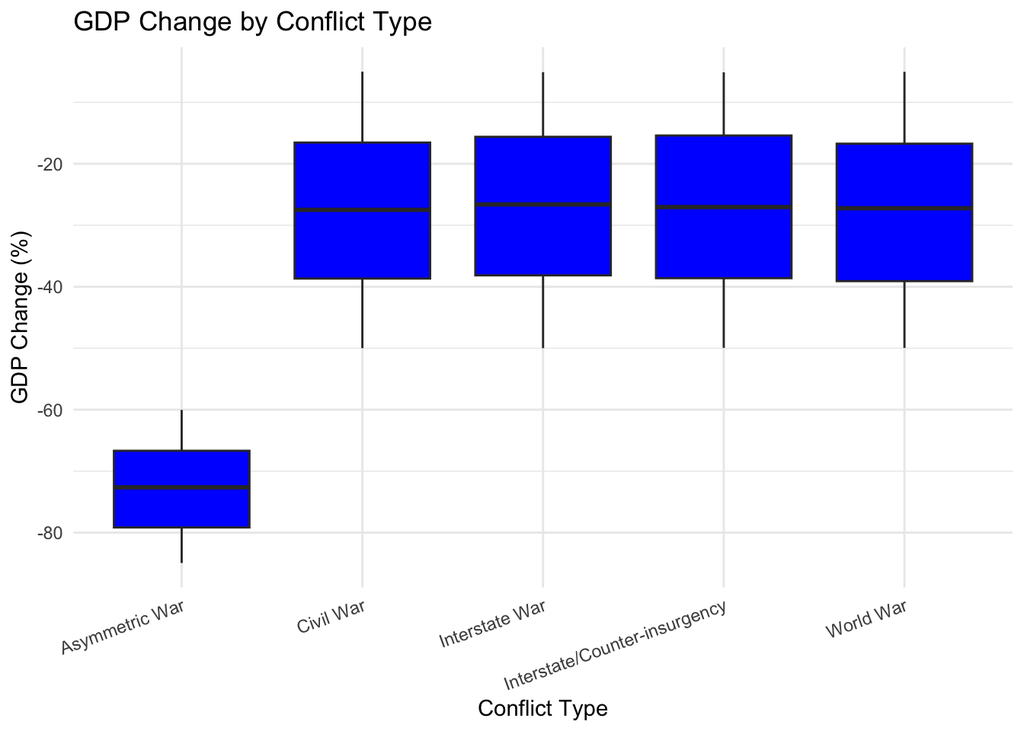

```r
data |>
  ggplot(aes(x = Conflict_Type, y = GDP_Change)) +
  geom_boxplot(fill = "blue") +
  labs(title = "GDP Change by Conflict Type",
       x = "Conflict Type", y = "GDP Change (%)") +
  theme_minimal() +
  theme(axis.text.x = element_text(angle = 20, hjust = 1))
```

Asymmetric war can be easily differentiated compared to other conflict types. Since GDP Change drops deeply by observing the median is around -70, and its ranges are more narrow. This means asymmetric wars have a more consistent and destructive impact on the economy. The other conflict types similar to each other with median around -28 and there does not appear to be a significant difference between these groups in terms of GDP decline.

### Inflation by Region (boxplot)

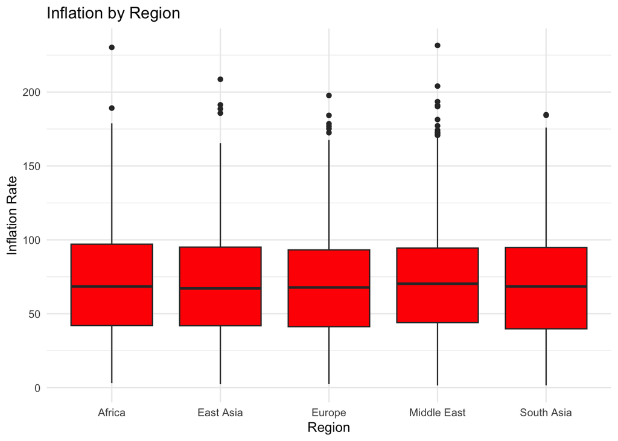

```r
data |>
  ggplot(aes(x = Region, y = Inflation_Rate)) +
  geom_boxplot(fill = "red") +
  labs(title = "Inflation by Region",
       x = "Region", y = "Inflation Rate") +
  theme_minimal()
```

### Unemployment Spike vs GDP Change (scatter)

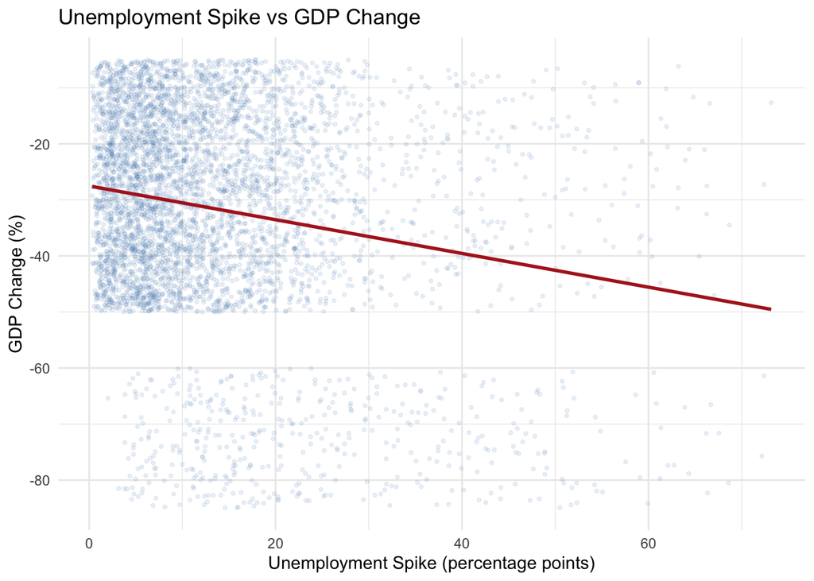

```r
data |>
  ggplot(aes(x = Unemployment_Spike, y = GDP_Change)) +
  geom_point(alpha = 0.1, color = "steelblue", size = 0.8) +
  geom_smooth(method = "lm", formula = y ~ x, color = "firebrick", se = FALSE) +
  labs(title = "Unemployment Spike vs GDP Change",
       x = "Unemployment Spike (percentage points)", y = "GDP Change (%)") +
  theme_minimal()
```

The plot shows a negative relationship between GDP Change and Unemployment Spike. As unemployment spike increases, the decline in GDP becomes deeper. Furthermore, point cloud is very wide, for every unemployment spike value, GDP Change spreads across a very broad range between -85 and -5. Other than this, there is concentration on the left side, this means the vast majority of observations are clustered at low unemployment spike values (0-20), while data becomes sparse at higher values (60+), meaning the trend line on the right side is less reliable.

Overall, there is a weak but meaningful negative relationship between the two variables, which justifies including `Unemployment_Spike` as a predictor in the regression models.

### Correlation Matrix

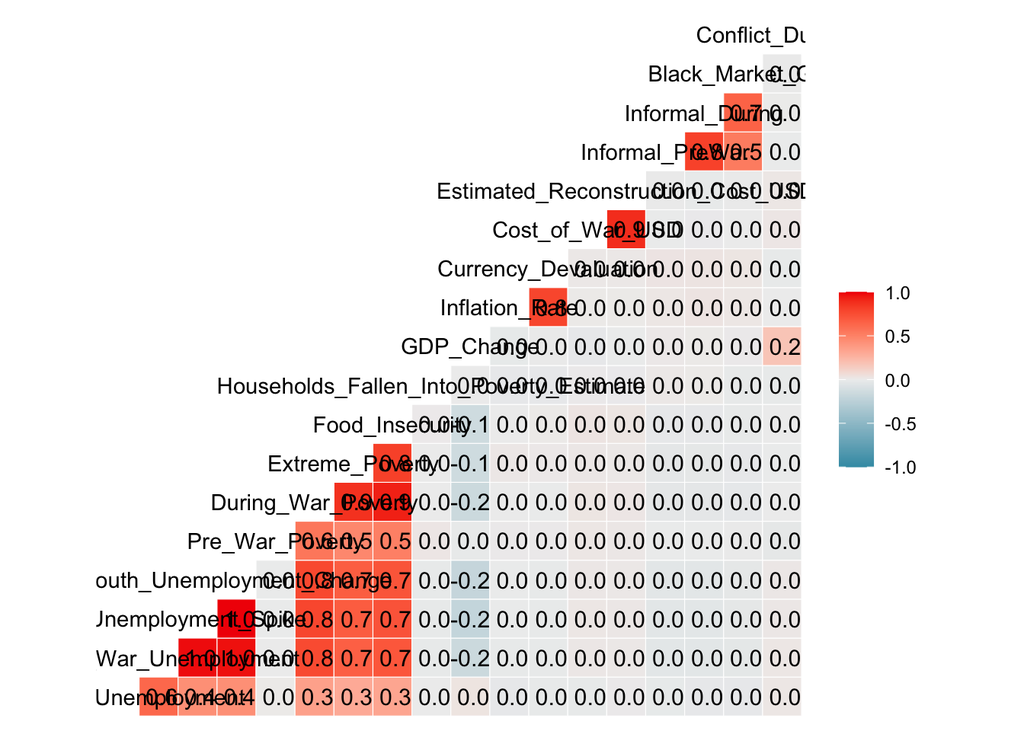

```r
GGally::ggcorr(dplyr::select(data, where(is.numeric), -Start_Year, -End_Year), label = TRUE)
```

Strong positive correlations:

- `Inflation_Rate` and `Currency_Devaluation` have 0.8 correlation
- `During_War_Poverty` and `Extreme_Poverty` have 0.9 correlation
- `During_War_Poverty` and `Pre_War_Poverty` have 0.5 correlation
- `During_War_Unemployment` and `Unemployment_Spike` have 1.0 correlation
- `Youth_Unemployment_Change` and `Unemployment_Spike` have 0.7 correlation
- `Informal_PreWar` and `Informal_During` have 0.5 correlation

Based on the correlation analysis, we remove highly correlated variables to avoid multicollinearity. We also remove free-text identifier columns that carry no predictive information. The following variables are kept: `Unemployment_Spike` from the unemployment group since it is the most direct measure of war’s impact on employment, `During_War_Poverty` from the poverty group since it is most directly relevant to war’s economic impact, and `Informal_During` from the informal economy group since it is more relevant during conflict.

```r
# Removing redundant and text variables
data <- data |>
    dplyr::select(-c(During_War_Unemployment,
                     Youth_Unemployment_Change,
                     Extreme_Poverty,
                     Pre_War_Poverty,
                     Informal_PreWar,
                     Currency_Devaluation,
                     Conflict_Name,                #since they are unique text
                     Primary_Country,              #text
                     Primary_Black_Market_Goods )) #text

# Convert remaining character columns to factors
data <- data |>
  mutate(
    Conflict_Type            = as.factor(Conflict_Type),
    Region                   = as.factor(Region),
    Status                   = as.factor(Status),
    Most_Affected_Sector     = as.factor(Most_Affected_Sector),
    War_Profiteering_Documented = as.factor(War_Profiteering_Documented),
    Black_Market_Activity_Level = as.factor(Black_Market_Activity_Level)
  )
```

## Class Balance of Target Variables

Before modelling, it is important to understand the distribution of our two target variables.

For the **classification target**, we check whether the classes are balanced:

```r
cat("Black Market Activity Level distribution:\n")
```

```
## Black Market Activity Level distribution:
```

```r
prop.table(table(data$Black_Market_Activity_Level))
```

```
##
## Dominant     High      Low Moderate
##   0.2440   0.2466   0.2478   0.2616
```

The four classes of Black_Market_Activity_Level are approximately equally distributed around 25% each, so no resampling technique is required.

For the **regression target**, we look at the summary of `GDP_Change`:

```r
summary(data$GDP_Change)
```

```
##    Min. 1st Qu.  Median    Mean 3rd Qu.    Max.
##  -84.94  -41.79  -29.56  -31.64  -17.31   -5.01
```

We are not applying a log transformation to `GDP_Change` because log transformation requires strictly positive values, and our variable ranges from -84.94 to -5.01. In addition, it is already on a bounded, interpretable scale since it does not have extreme range.

### Train and Test Split

```r
set.seed(2026)
in_train <- createDataPartition(data$Black_Market_Activity_Level, p = 0.8, list = FALSE)
train_df <- data[in_train, ]
test_df  <- data[-in_train, ]

cat("Training set:", nrow(train_df), "observations\n")
```

```
## Training set: 4002 observations
```

```r
cat("Test set:", nrow(test_df), "observations\n")
```

```
## Test set: 998 observations
```

# Classification (emphasis on interpretation)

Since `Black_Market_Activity_Level` has 4 classes, we simplify it into a binary variable to enable logistic regression and ensure comparability across all classification models.

### Create the binary target

```r
train_df <- train_df |>
  mutate(BM_High = factor(
    Black_Market_Activity_Level %in% c("High", "Dominant"),
    levels = c(FALSE, TRUE),
    labels = c("Low_Moderate", "High_Dominant")))

test_df <- test_df |>
  mutate(BM_High = factor(
    Black_Market_Activity_Level %in% c("High", "Dominant"),
    levels = c(FALSE, TRUE),
    labels = c("Low_Moderate", "High_Dominant")
  ))

cat("Binary target distribution:\n")
```

```
## Binary target distribution:
```

```r
prop.table(table(train_df$BM_High))
```

```
##
##  Low_Moderate High_Dominant
##     0.5094953     0.4905047
```

### Fitting full logistic regression + stepwise selection

```r
logit_full <- glm(BM_High ~ . -Black_Market_Activity_Level -GDP_Change,
                  family = binomial(link = "logit"),
                  data = train_df)
logit_model <- step(logit_full, direction = "both", trace = 0)

selected_terms <- attr(terms(logit_model), "term.labels")
selected_formula <- as.formula(paste("BM_High ~", paste(selected_terms, collapse = " + ")))

cat("Selected predictors:", paste(selected_terms, collapse = ", "), "\n")
```

```
## Selected predictors: Status, Pre_War_Unemployment, Unemployment_Spike, Households_Fallen_Into_Poverty_Estimate, Informal_During, Black_Market_Gap
```

### Interpret coefficients

```r
summary(logit_model)
```

```
##
## Call:
## glm(formula = BM_High ~ Status + Pre_War_Unemployment + Unemployment_Spike +
##     Households_Fallen_Into_Poverty_Estimate + Informal_During +
##     Black_Market_Gap, family = binomial(link = "logit"), data = train_df)
##
## Coefficients:
##                                           Estimate Std. Error z value Pr(>|z|)
## (Intercept)                             -8.813e-02  1.261e-01  -0.699  0.48453
## StatusResolved                          -1.021e-01  6.832e-02  -1.494  0.13506
## Pre_War_Unemployment                     2.781e-02  1.021e-02   2.724  0.00644
## Unemployment_Spike                      -5.457e-03  3.190e-03  -1.711  0.08717
## Households_Fallen_Into_Poverty_Estimate -6.720e-08  4.884e-08  -1.376  0.16884
## Informal_During                         -3.251e-03  1.987e-03  -1.636  0.10179
## Black_Market_Gap                         7.579e-04  2.665e-04   2.844  0.00446
##
## (Intercept)
## StatusResolved
## Pre_War_Unemployment                    **
## Unemployment_Spike                      .
## Households_Fallen_Into_Poverty_Estimate
## Informal_During
## Black_Market_Gap                        **
## ---
## Signif. codes:  0 '***' 0.001 '**' 0.01 '*' 0.05 '.' 0.1 ' ' 1
##
## (Dispersion parameter for binomial family taken to be 1)
##
##     Null deviance: 5546.5  on 4001  degrees of freedom
## Residual deviance: 5528.0  on 3995  degrees of freedom
## AIC: 5542
##
## Number of Fisher Scoring iterations: 3
```

**Model Fit**

AIC: 5541.6

### Predict and evaluate

```r
logit_prob <- predict(logit_model, newdata = test_df, type = "response")
logit_pred <- factor(ifelse(logit_prob > 0.5, "High_Dominant",
                            "Low_Moderate"),
                     levels = c("Low_Moderate", "High_Dominant"))


cm_logit <- confusionMatrix(logit_pred, test_df$BM_High, positive = "High_Dominant")
cm_logit
```

```
## Confusion Matrix and Statistics
##
##                Reference
## Prediction      Low_Moderate High_Dominant
##   Low_Moderate           321           306
##   High_Dominant          187           184
##
##                Accuracy : 0.506
##                  95% CI : (0.4745, 0.5375)
##     No Information Rate : 0.509
##     P-Value [Acc > NIR] : 0.5878
##
##                   Kappa : 0.0074
##
##  Mcnemar's Test P-Value : 1.07e-07
##
##             Sensitivity : 0.3755
##             Specificity : 0.6319
##          Pos Pred Value : 0.4960
##          Neg Pred Value : 0.5120
##              Prevalence : 0.4910
##          Detection Rate : 0.1844
##    Detection Prevalence : 0.3717
##       Balanced Accuracy : 0.5037
##
##        'Positive' Class : High_Dominant
##
```

# Classification (emphasis on modelling and prediction)

```r
selected_formula = BM_High ~ Pre_War_Unemployment + Informal_During + Black_Market_Gap
```

## 1. LDA

```r
lda_model <- lda(selected_formula, data = train_df)
lda_pred <- predict(lda_model, newdata = test_df)$class

cm_lda <- confusionMatrix(lda_pred, test_df$BM_High, positive = "High_Dominant")
cm_lda
```

```
## Confusion Matrix and Statistics
##
##                Reference
## Prediction      Low_Moderate High_Dominant
##   Low_Moderate           333           324
##   High_Dominant          175           166
##
##                Accuracy : 0.5
##                  95% CI : (0.4685, 0.5315)
##     No Information Rate : 0.509
##     P-Value [Acc > NIR] : 0.7263
##
##                   Kappa : -0.0057
##
##  Mcnemar's Test P-Value : 3.463e-11
##
##             Sensitivity : 0.3388
##             Specificity : 0.6555
##          Pos Pred Value : 0.4868
##          Neg Pred Value : 0.5068
##              Prevalence : 0.4910
##          Detection Rate : 0.1663
##    Detection Prevalence : 0.3417
##       Balanced Accuracy : 0.4971
##
##        'Positive' Class : High_Dominant
##
```

Key Metrics

```
Accuracy : 0.5
Balanced Accuracy : 0.4971
Sensitivity : 0.3388
Specificity : 0.6555
```

We observe that LDA almost identically performs as logistic regression. This is expected since LDA is also a linear classifier and the classes don’t separate linearly with these three predictors.

## 2. QDA

```r
qda_model <- qda(selected_formula, data = train_df)
qda_pred <- predict(qda_model, newdata = test_df)$class

cm_qda <- confusionMatrix(qda_pred, test_df$BM_High, positive = "High_Dominant")
cm_qda
```

```
## Confusion Matrix and Statistics
##
##                Reference
## Prediction      Low_Moderate High_Dominant
##   Low_Moderate           310           293
##   High_Dominant          198           197
##
##                Accuracy : 0.508
##                  95% CI : (0.4765, 0.5395)
##     No Information Rate : 0.509
##     P-Value [Acc > NIR] : 0.5379
##
##                   Kappa : 0.0123
##
##  Mcnemar's Test P-Value : 2.214e-05
##
##             Sensitivity : 0.4020
##             Specificity : 0.6102
##          Pos Pred Value : 0.4987
##          Neg Pred Value : 0.5141
##              Prevalence : 0.4910
##          Detection Rate : 0.1974
##    Detection Prevalence : 0.3958
##       Balanced Accuracy : 0.5061
##
##        'Positive' Class : High_Dominant
##
```

Key Metrics:

```
Accuracy : 0.508
Balanced Accuracy : 0.5061
Sensitivity : 0.4020
Specificity : 0.6102
```

QDA performs slightly better than LDA with a Balanced Accuracy of 0.506, suggesting that allowing quadratic decision boundaries provides a marginal improvement, though the gain is negligible.

## 3. Naive Bayes

```r
nb_model <- naiveBayes(selected_formula, data = train_df)
nb_pred <- predict(nb_model, newdata = test_df)

cm_nb <- confusionMatrix(nb_pred, test_df$BM_High, positive = "High_Dominant")
cm_nb
```

```
## Confusion Matrix and Statistics
##
##                Reference
## Prediction      Low_Moderate High_Dominant
##   Low_Moderate           383           342
##   High_Dominant          125           148
##
##                Accuracy : 0.5321
##                  95% CI : (0.5006, 0.5634)
##     No Information Rate : 0.509
##     P-Value [Acc > NIR] : 0.07708
##
##                   Kappa : 0.0564
##
##  Mcnemar's Test P-Value : < 2e-16
##
##             Sensitivity : 0.3020
##             Specificity : 0.7539
##          Pos Pred Value : 0.5421
##          Neg Pred Value : 0.5283
##              Prevalence : 0.4910
##          Detection Rate : 0.1483
##    Detection Prevalence : 0.2735
##       Balanced Accuracy : 0.5280
##
##        'Positive' Class : High_Dominant
##
```

Key Metrics

```
Accuracy : 0.5321
Balanced Accuracy : 0.5280
Sensitivity : 0.3020
Specificity : 0.7539
```

Naive Bayes is slightly better than LDA and QDA. Still weak but showing a small improvement. Notably Specificity is 0.754 which means it is quite good at identifying Low_Moderate cases, but Sensitivity is only 0.302 so it misses a lot of High_Dominant cases.

## 4. k-NN with CV tuning + scree plot

```r
ctrl_knn <- trainControl(method = "cv", number = 5)
knn_grid <- data.frame(k = c(1, 3, 5, 7, 9, 11, 15, 20))

knn_model <- train(
  selected_formula,
  data = train_df,
  method = "knn",
  preProcess = c("center", "scale"),
  trControl = ctrl_knn,
  tuneGrid = knn_grid,
  metric = "Accuracy"
)

knn_pred <- predict(knn_model, newdata = test_df)

cm_knn <- confusionMatrix(knn_pred, test_df$BM_High, positive = "High_Dominant")
cm_knn
```

```
## Confusion Matrix and Statistics
##
##                Reference
## Prediction      Low_Moderate High_Dominant
##   Low_Moderate           253           238
##   High_Dominant          255           252
##
##                Accuracy : 0.506
##                  95% CI : (0.4745, 0.5375)
##     No Information Rate : 0.509
##     P-Value [Acc > NIR] : 0.5878
##
##                   Kappa : 0.0123
##
##  Mcnemar's Test P-Value : 0.4712
##
##             Sensitivity : 0.5143
##             Specificity : 0.4980
##          Pos Pred Value : 0.4970
##          Neg Pred Value : 0.5153
##              Prevalence : 0.4910
##          Detection Rate : 0.2525
##    Detection Prevalence : 0.5080
##       Balanced Accuracy : 0.5062
##
##        'Positive' Class : High_Dominant
##
```

```r
# Best k
best_k <- knn_model$bestTune$k
cat("Best k selected by CV:", best_k, "\n")
```

```
## Best k selected by CV: 3
```

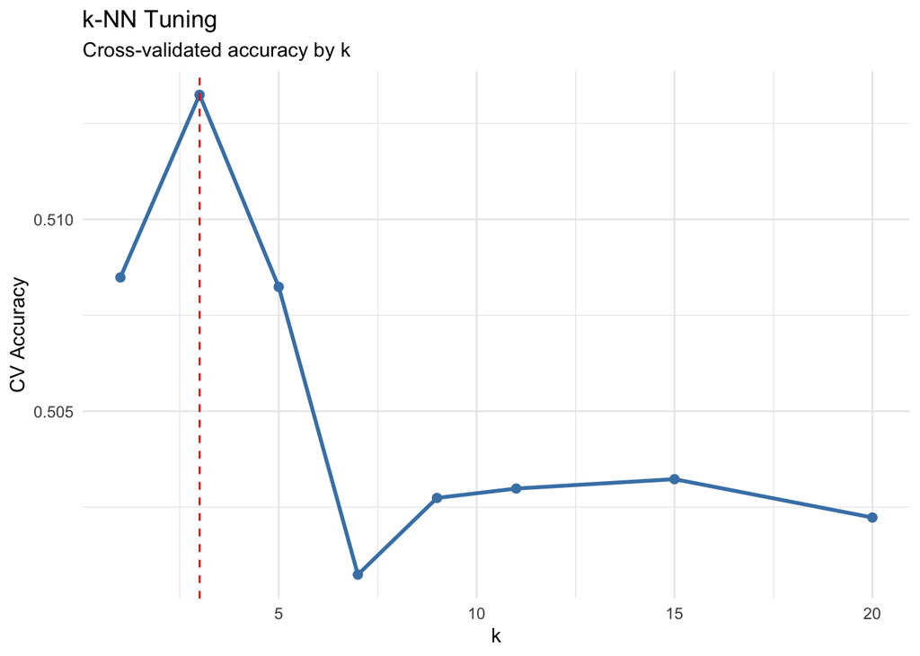

```r
# Scree plot
ggplot(knn_model$results, aes(x = k, y = Accuracy)) +
  geom_line(color = "steelblue", linewidth = 1) +
  geom_point(color = "steelblue", size = 2) +
  geom_vline(xintercept = best_k, linetype = "dashed", color = "red") +
  labs(title = "k-NN Tuning",
       subtitle = "Cross-validated accuracy by k",
       x = "k", y = "CV Accuracy") +
  theme_minimal()
```

Key Metrics

```
Accuracy : 0.506
Balanced Accuracy : 0.5062
Sensitivity : 0.5143
Specificity : 0.4980
Best k selected by CV: 3
```

k-NN with k=3 achieves a Balanced Accuracy of 0.506, similar to LDA and QDA. The scree plot shows accuracy peaking at k=3 before declining, confirming this as the optimal neighbourhood size.

## 5. Decision Tree

Cross-validation via `cv.tree()` failed because during the cross-validation folds the tree collapsed to a single node — a known limitation of the `tree` package when the classes are difficult to separate. Since all previous models also showed weak separability of the binary target, this is consistent with the overall pattern observed. Instead, we manually pruned the tree to a size of 10 terminal nodes, which provides a balance between complexity and interpretability.

```r
tree_formula <- BM_High ~ . - Black_Market_Activity_Level - GDP_Change

tree_model <- tree(tree_formula,
                   data = train_df,
                   control = tree.control(nobs = nrow(train_df),
                                         mincut = 5,
                                         minsize = 10,
                                         mindev = 0.001))

summary(tree_model)
```

```
##
## Classification tree:
## tree(formula = tree_formula, data = train_df, control = tree.control(nobs = nrow(train_df),
##     mincut = 5, minsize = 10, mindev = 0.001))
## Variables actually used in tree construction:
##  [1] "Households_Fallen_Into_Poverty_Estimate"
##  [2] "Pre_War_Unemployment"
##  [3] "Black_Market_Gap"
##  [4] "Most_Affected_Sector"
##  [5] "Cost_of_War_USD"
##  [6] "Estimated_Reconstruction_Cost_USD"
##  [7] "Informal_During"
##  [8] "Food_Insecurity"
##  [9] "Start_Year"
## [10] "Inflation_Rate"
## [11] "During_War_Poverty"
## [12] "Unemployment_Spike"
## [13] "Region"
## Number of terminal nodes:  93
## Residual mean deviance:  1.211 = 4736 / 3909
## Misclassification error rate: 0.3776 = 1511 / 4002
```

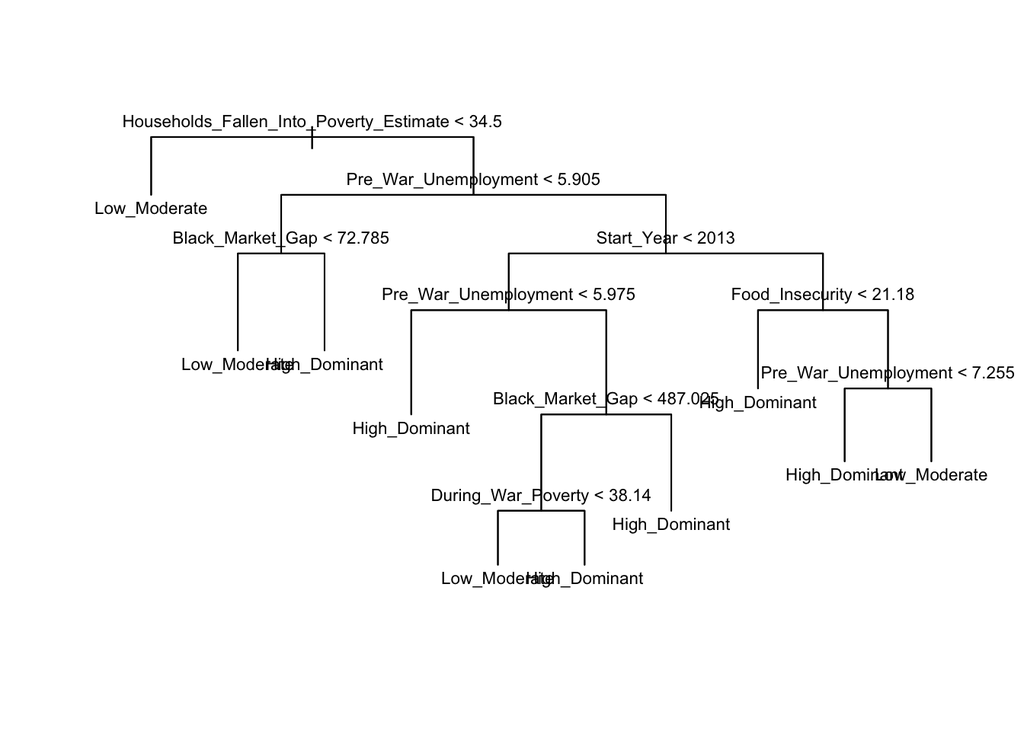

```r
# Manually prune to size 10
tree_pruned <- prune.misclass(tree_model, best = 10)

# Plot the pruned tree
plot(tree_pruned)
text(tree_pruned, pretty = 0, cex = 0.7)
```

```r
# Predict
tree_pred <- predict(tree_pruned, newdata = test_df, type = "class")

cm_tree <- confusionMatrix(tree_pred, test_df$BM_High, positive = "High_Dominant")
cm_tree
```

```
## Confusion Matrix and Statistics
##
##                Reference
## Prediction      Low_Moderate High_Dominant
##   Low_Moderate           337           286
##   High_Dominant          171           204
##
##                Accuracy : 0.5421
##                  95% CI : (0.5106, 0.5733)
##     No Information Rate : 0.509
##     P-Value [Acc > NIR] : 0.01974
##
##                   Kappa : 0.08
##
##  Mcnemar's Test P-Value : 9.677e-08
##
##             Sensitivity : 0.4163
##             Specificity : 0.6634
##          Pos Pred Value : 0.5440
##          Neg Pred Value : 0.5409
##              Prevalence : 0.4910
##          Detection Rate : 0.2044
##    Detection Prevalence : 0.3758
##       Balanced Accuracy : 0.5399
##
##        'Positive' Class : High_Dominant
##
```

**Tree structure:** 93 terminal nodes, using 13 variables — `Households_Fallen_Into_Poverty_Estimate`, `Pre_War_Unemployment`, `Black_Market_Gap` are the most prominent splits visible in the tree plot.

Key metrics:

```
Accuracy : 0.542
Balanced Accuracy : 0.540
Sensitivity : 0.416
Specificity : 0.663
```

The Decision Tree is the best performing model so far with a Balanced Accuracy of 0.540 and an accuracy that is statistically significantly better than random guessing (p = 0.019).